# Lecture 7A Exercises

your name

# Correlation vs linear model

- Linear association between two variables can be described by correlation, but
- a multiple regression model can describe linear relationship between a response variable and many explanatory variables.

For two variables $X, Y$, correlation is:

$$r=\frac{\sum_{i=1}^{n} (x_i-\bar{x})(y_i-\bar{y})}{\sqrt{\sum_{i=1}^{n}(x_i-\bar{x})^2}\sqrt{\sum_{i=1}^{n}(y_i-\bar{y})^2}} = \frac{cov(X,Y)}{s_xs_y}$$

# Correlation

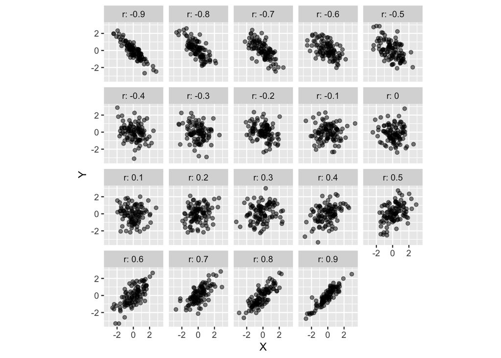

# Simple regression

$$y_i=\beta_0+\beta_1x_{i}+\varepsilon_i, ~~~ i=1, \dots, n$$

where (least squares) estimates for $\beta_0, \beta_1$ are:

$$b_1 = r\frac{s_y}{s_x}, ~~~~~~~~ b_0=\bar{y}-b_1\bar{x}$$

Slope is related to correlation, but it also depends on the variation of observations, in both of the variables.

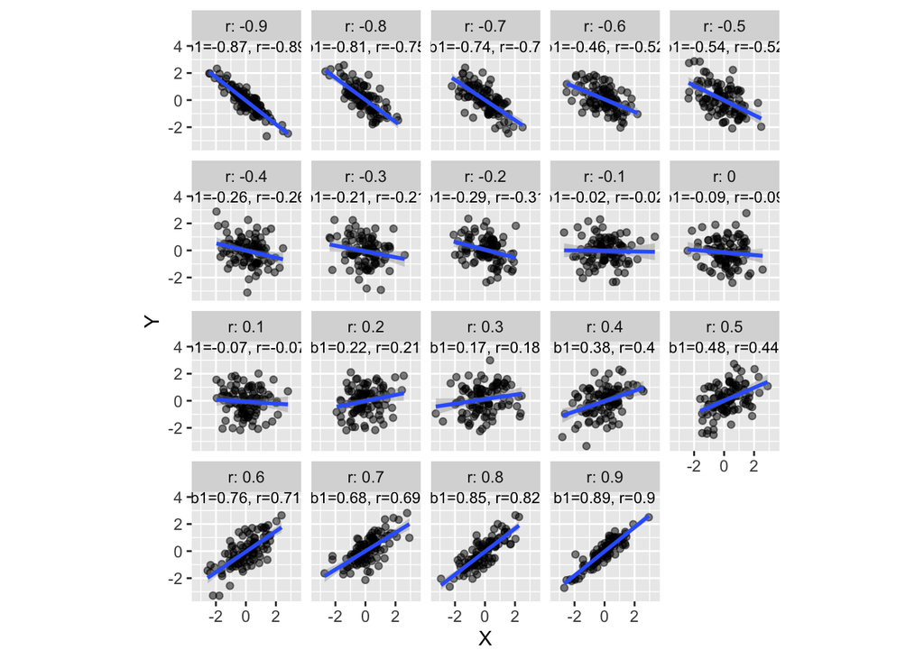

### Multiple regression model

$$y_i=\beta_0+\beta_1x_{i1}+\dots +\beta_px_{ip}+\varepsilon_i, ~~~ i=1, \dots, n$$
where $\varepsilon$ is a sample from a normal distribution, $N(0, \sigma^2)$.

### What a model says

- The fitted model allows us to predict a value for the response, e.g.
  - Suppose $\widehat{y}=2+3x+x^2-2x^3$, then for $x=0.5, \widehat{y}=2+3*0.5+0.5^2-2*0.5^3=3.5$
  - Suppose $\widehat{y}=3\exp(2x)$, then for $x=-1, \widehat{y}=3\exp(2*(-1))=0.406$
- How useful the model prediction is depends on the residual error. If the model explains little of the relationship then the residual error will be large and predictions less useful.
- Predictions within the domain of the explanatory variables used to fit the model will be more reliable than **extrapolating** outside the domain. Particularly this is true for nonlinear models.

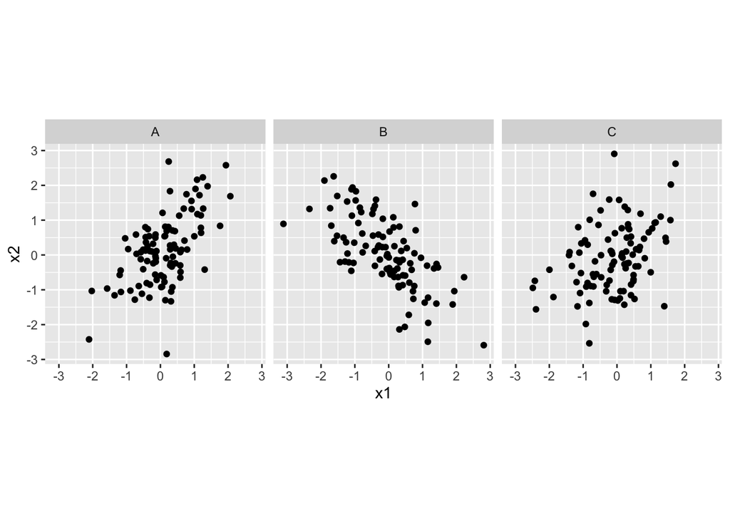

### Questions

- Which plot has correlation about -0.7?
- Which plot has correlation about 0.6?
- Which plot has correlation about 0.4?

# Part 1: modelling

## Let’s fit a model to CO2

First we read in the data

```r
library(lubridate)
co2_spo <- read_csv("http://scrippsco2.ucsd.edu/assets/data/atmospheric/stations/merged_in_situ_and_flask/daily/daily_merge_co2_spo.csv",
                    col_names = c("date",
                                  "time",
                                  "day",
                                  "decdate",
                                  "n",
                                  "flg",
                                  "co2"),
                    skip = 69) %>%
  mutate(lat = -90.0,
         lon = 0,
         stn = "spo") %>%
  filter(flg == 0) %>%
  mutate(date = ymd(date)) %>%
#   First we re-scale to start from 1 until the number of days in the time frame.
  mutate(day0 = day - min(day))
co2_spo
```

```
## # A tibble: 1,196 x 11
##    date       time     day decdate     n   flg   co2   lat   lon stn
##    <date>     <tim>  <dbl>   <dbl> <dbl> <dbl> <dbl> <dbl> <dbl> <chr>
##  1 1957-06-17 00:00 20988    1957.     1     0  313.   -90     0 spo
##  2 1957-12-22 00:00 21176    1958.     1     0  314.   -90     0 spo
##  3 1957-12-23 00:00 21177    1958.     1     0  314.   -90     0 spo
##  4 1958-03-21 00:00 21265    1958.     1     0  314.   -90     0 spo
##  5 1958-03-22 06:30 21266.   1958.     2     0  314.   -90     0 spo
##  6 1958-06-20 00:00 21356    1958.     1     0  315.   -90     0 spo
##  7 1958-09-27 00:00 21455    1959.     1     0  315.   -90     0 spo
##  8 1958-09-28 00:00 21456    1959.     1     0  315.   -90     0 spo
##  9 1959-01-08 00:00 21558    1959.     1     0  315.   -90     0 spo
## 10 1959-01-12 00:00 21562    1959.     1     0  315.   -90     0 spo
## # … with 1,186 more rows, and 1 more variable: day0 <dbl>
```

### Task: plot date against co2 with points

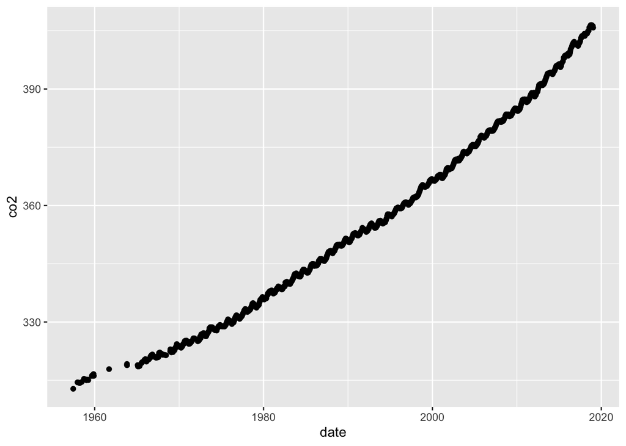

```r
ggplot(co2_spo,
       aes(x = date,
           y = co2)) +
  geom_point()
```

### Task: fit a linear model, using `day` variable as the explanatory variable.

# calculate the summary of day0 and day to compare `day` against `day0`

```r
summary(co2_spo$day)
```

```
##    Min. 1st Qu.  Median    Mean 3rd Qu.    Max.
##   20988   28898   33764   33624   38508   43480
```

```r
summary(co2_spo$day0)
```

```
##    Min. 1st Qu.  Median    Mean 3rd Qu.    Max.
##       0    7910   12776   12636   17520   22492
```

# question: “What is range of dates of this data?”

## Task: fit a linear model, predicting co2 using day0

```r
co2_fit <- lm(co2 ~ day0, data = co2_spo)
co2_fit
```

```
##
## Call:
## lm(formula = co2 ~ day0, data = co2_spo)
##
## Coefficients:
## (Intercept)         day0
##   3.020e+02    4.287e-03
```

Now we tidy up the output and store information on the intercept and slope so we can describe the fit

```r
library(broom)
tidy_co2_fit <- tidy(co2_fit)
tidy_co2_fit
```

```
## # A tibble: 2 x 5
##   term         estimate std.error statistic p.value
##   <chr>           <dbl>     <dbl>     <dbl>   <dbl>
## 1 (Intercept) 302.      0.221         1367.       0
## 2 day0          0.00429 0.0000159      269.       0
```

```r
int <- round(tidy_co2_fit$estimate[1], 4)
slope <- round(tidy_co2_fit$estimate[2], 4)
```

# Task: Predict from the model

- For day0=10000
- the model predicts co2 to be 302.0302+0.0043*10000 = 345.0302.

## Question: What date is day0=10000? (Hint: use filter and select on the data to work it out)"

# Model basics in R

- Formula
  - `response ~ explanatory` specifies the reponse variable and explanatory variable from the data
  - e.g. `y ~ x1+x2+x3` three explanatory variables to be used to model response, main effects only
  - `y ~ x1*x2*x3` include interaction terms
  - `y ~ x - 1` specifies to force model to go through 0, that $b_0$ will be set to 0.
- Extract components using the broom package
  - `tidy` extracts the coefficients
  - `augment` extracts residuals and fitted values, and pointwise diagnostics
  - `glance` extracts model fit summaries

# Plot the model

We can use the `augment` function to extract residuals and fitted values, and pointwise diagnostics

```r
co2_model <- augment(co2_fit, co2_spo)

co2_model
```

```
## # A tibble: 1,196 x 18
##    date       time     day decdate     n   flg   co2   lat   lon stn
##    <date>     <tim>  <dbl>   <dbl> <dbl> <dbl> <dbl> <dbl> <dbl> <chr>
##  1 1957-06-17 00:00 20988    1957.     1     0  313.   -90     0 spo
##  2 1957-12-22 00:00 21176    1958.     1     0  314.   -90     0 spo
##  3 1957-12-23 00:00 21177    1958.     1     0  314.   -90     0 spo
##  4 1958-03-21 00:00 21265    1958.     1     0  314.   -90     0 spo
##  5 1958-03-22 06:30 21266.   1958.     2     0  314.   -90     0 spo
##  6 1958-06-20 00:00 21356    1958.     1     0  315.   -90     0 spo
##  7 1958-09-27 00:00 21455    1959.     1     0  315.   -90     0 spo
##  8 1958-09-28 00:00 21456    1959.     1     0  315.   -90     0 spo
##  9 1959-01-08 00:00 21558    1959.     1     0  315.   -90     0 spo
## 10 1959-01-12 00:00 21562    1959.     1     0  315.   -90     0 spo
## # … with 1,186 more rows, and 8 more variables: day0 <dbl>, .fitted <dbl>,
## #   .se.fit <dbl>, .resid <dbl>, .hat <dbl>, .sigma <dbl>, .cooksd <dbl>,
## #   .std.resid <dbl>
```

plot the date and co2 with points and add in the line

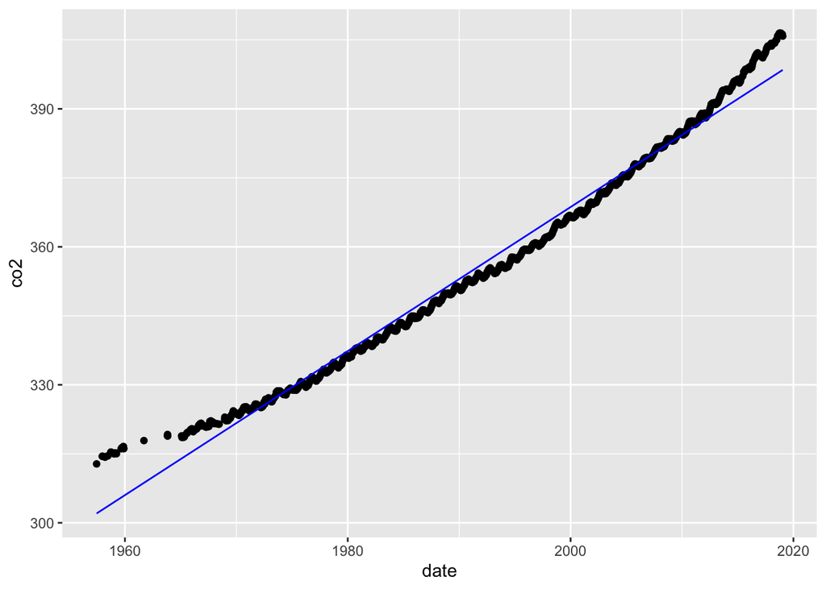

```r
ggplot(co2_model,
       aes(x = date,
           y = co2)) +
  geom_point() +
  geom_line(aes(y = .fitted), colour = "blue")
```

### Examine residuals

- **Residuals** are calculated for each observed $y$ by computing the difference: $y_i-\widehat{y_i}$.
- Plotting the residuals against fitted values (or x in simple linear models) can reveal problems with the fit.

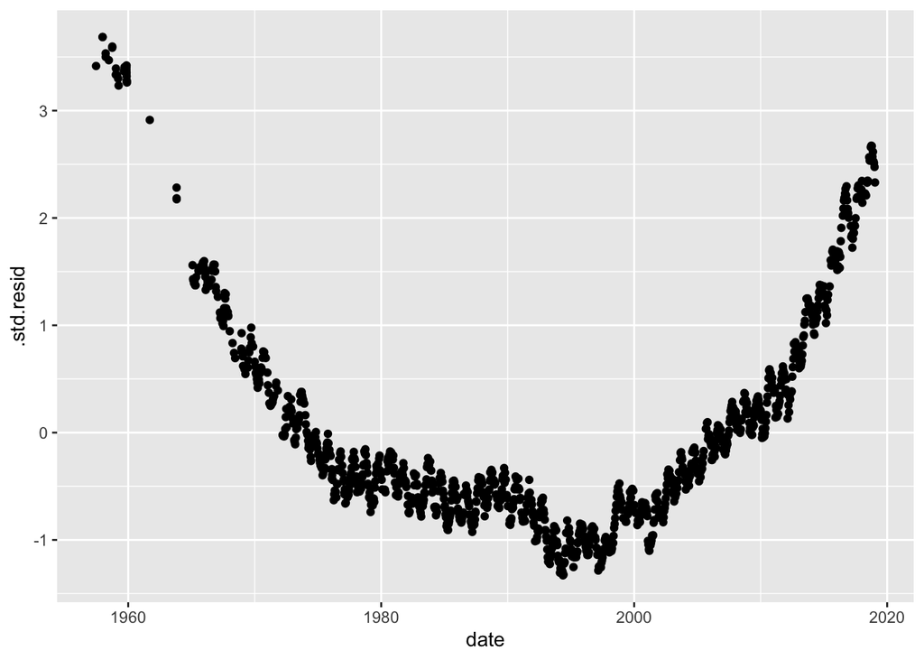

```r
ggplot(co2_model,
       aes(x = date,
           y = .std.resid)) +
  geom_point()
```

# Assessment of fit

- The relationship between co2 and day0 is nonlinear!
- The linear model does a reasonable job of explaining the increasing trend over time, but it especially mismatches the observed data at the ends, and middle of the time period.

### Your turn

- Try to add a quadratic term (in day0), or more, to the model to improve the fit.
- repeat a similar process to what you have seen earlier when exploring model fit
- Hints: (1) you may want to centre the day0 values, or even standardise them, to get a nice quadratic form, (2) If the fit is good, your residual vs fitted plot should have values evenly spread above and below 0, and relatively even across the time span.

```r
co2_sq <- co2_spo %>%
  mutate(day0sq = (day0-median(day0))^2)

co2_fit2 <- lm(co2 ~ day0 + day0sq, data = co2_sq)

tidy(co2_fit2)
```

```
## # A tibble: 3 x 5
##   term        estimate std.error statistic p.value
##   <chr>          <dbl>     <dbl>     <dbl>   <dbl>
## 1 (Intercept)  2.98e+2  6.49e- 2     4586.       0
## 2 day0         4.38e-3  4.12e- 6     1062.       0
## 3 day0sq       9.40e-8  7.19e-10      131.       0
```

```r
co2_model2 <- augment(co2_fit2, co2_sq)
```

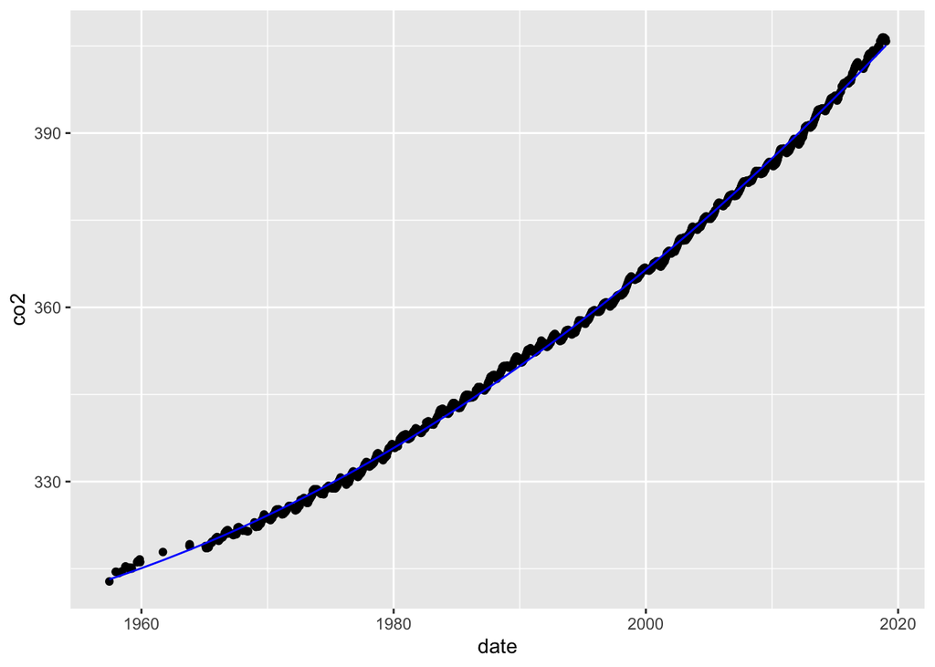

```r
ggplot(co2_model2,
       aes(x = date, y = co2)) +
  geom_point() +
  geom_line(aes(y = .fitted), colour="blue")
```

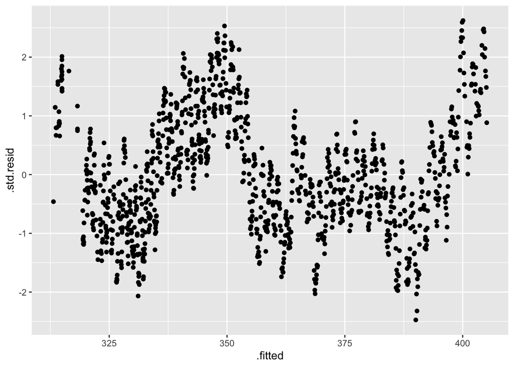

```r
ggplot(co2_model2,
       aes(x = .fitted, y = .std.resid)) +
  geom_point()
```

```r
co2_fit3 <- lm(co2~ day0 + I(day0^2), data = co2_sq)

tidy(co2_fit3)
```

```
## # A tibble: 3 x 5
##   term        estimate std.error statistic p.value
##   <chr>          <dbl>     <dbl>     <dbl>   <dbl>
## 1 (Intercept)  3.13e+2  1.02e- 1     3067.       0
## 2 day0         1.97e-3  1.82e- 5      109.       0
## 3 I(day0^2)    9.40e-8  7.19e-10      131.       0
```

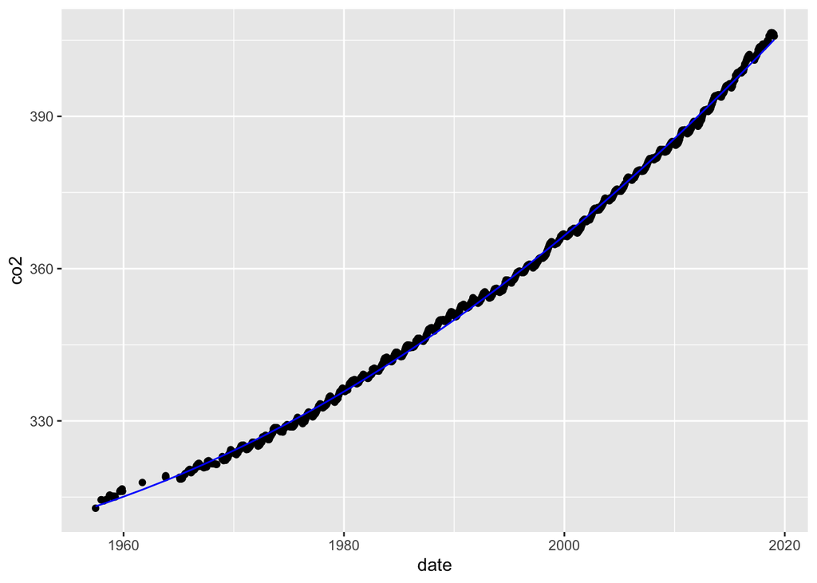

```r
co2_model3 <- augment(co2_fit3, co2_spo)

ggplot(co2_model3, aes(x=date, y=co2)) +
  geom_point() +
  geom_line(aes(y=.fitted), colour="blue")
```

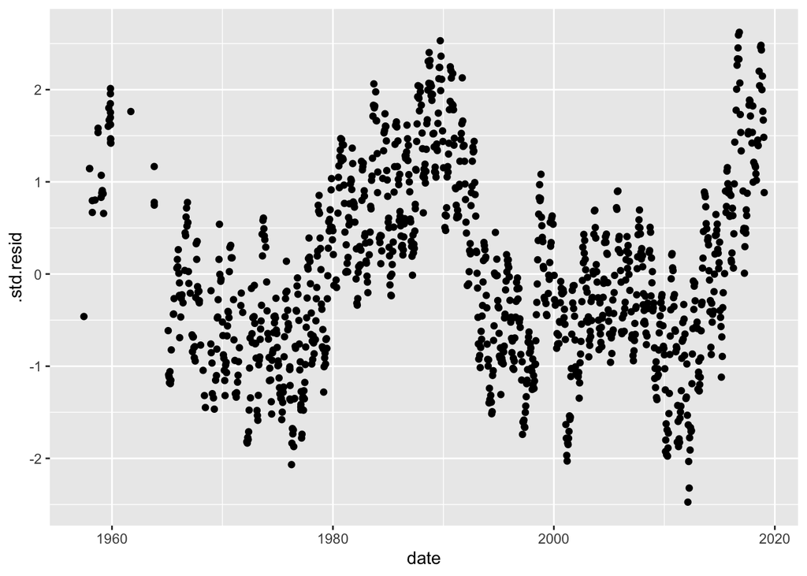

```r
ggplot(co2_model3, aes(x=date, y=.std.resid)) +
  geom_point()
```

## Your Turn: Predict co2 at another location

Using your model, built using values collected the south pole sensor, see how well it fits values from Point Barrow, Alaska.

1. Download the data. You can use almost the same code as for SPO but check the file name at http://scrippsco2.ucsd.edu/data/atmospheric_co2/ptb.
2. The code below is a way to fit new data. It needs a bit of modification.

```
co2_model_ptb <- augment(co2_fit2, newdata=co2_ptb)
```

3. Plot the data, and overlay the fitted model. You can use code like this.

```
ggplot(co2_model, aes(x=date, y=co2)) +
  geom_point() +
  geom_line(aes(y=.fitted), colour="blue")
```

## Seasonality

- If you plot the residuals on a short time frame, you can see that there is some seasonality. Values are high in spring, and low in autumn!
- Brainstorm with your table members - yes, please talk with each other - ideas on how to fit a model that takes seasonality into account. There are multiple solutions, and maybe some that we haven’t thought of.